# 03 Analyzing word and document frequency: tf-idf

H. David Shea

30 Jul 2021

In these exercises, we are focused on determining “what a document is about”. The approach is to look at *term frequency* (tf) of words in a document - trying to determine which words are “important” in the text. But some words - for instance, stop words - can be used frequently but may just occur naturally in high frequency. So, an alternative is to look at *inverse document frequency* (idf), where we decrease the weight for commonly used words and increase the weight of more infrequent words. (Frequency here is measured over collections of documents.)

“The statistic tf-idf is intended to measure how important a word is to a document in a collection (or corpus) of documents, for example, to one novel in a collection of novels or to one website in a collection of websites.”

$$idf(\text{term}) = \ln{\left(\frac{n_{\text{documents}}}{n_{\text{documents containing term}}}\right)}$$

## Term frequency in Jane Austen’s novels

Word count per novel.

```r
book_words <- austen_books() %>%
    unnest_tokens(word, text) %>%
    count(book, word, sort = TRUE)

total_words <- book_words %>%
    group_by(book) %>%
    summarize(total = sum(n))

book_words <- left_join(book_words, total_words, by = "book")

book_words %>%
    slice_max(n, n = 10) %>%
    kable()
```

| book | word | n | total |
| --- | --- | --- | --- |
| Mansfield Park | the | 6206 | 160460 |
| Mansfield Park | to | 5475 | 160460 |
| Mansfield Park | and | 5438 | 160460 |
| Emma | to | 5239 | 160996 |
| Emma | the | 5201 | 160996 |
| Emma | and | 4896 | 160996 |
| Mansfield Park | of | 4778 | 160460 |
| Pride & Prejudice | the | 4331 | 122204 |
| Emma | of | 4291 | 160996 |
| Pride & Prejudice | to | 4162 | 122204 |

Term frequency per novel.

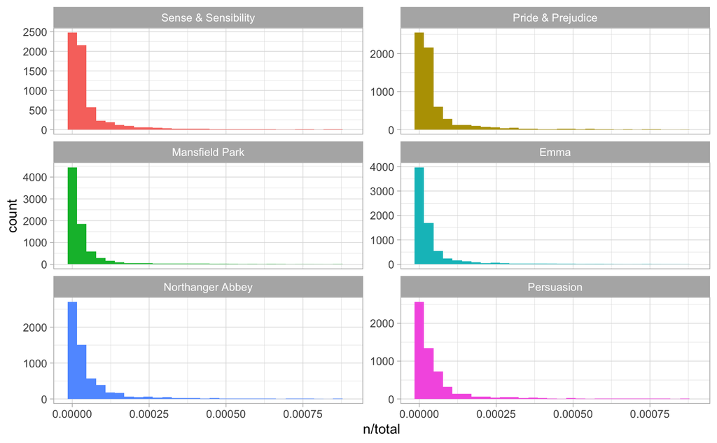

Term frequency distribution in Jane Austen’s novels

```r
ggplot(book_words, aes(n / total, fill = book)) +
    geom_histogram(show.legend = FALSE, na.rm = TRUE) +
    xlim(NA, 0.0009) +
    facet_wrap( ~ book, ncol = 2, scales = "free_y") +
    theme_light()
```

Note: the distribution is similar across all novels - “many words that occur rarely and fewer words that occur frequently”.

## Zipf’s law

“Zipf’s law states that the frequency that a word appears is inversely proportional to its rank.”

```r
freq_by_rank <- book_words %>%
    group_by(book) %>%
    mutate(rank = row_number(),
           `term frequency` = n / total) %>%
    ungroup()

freq_by_rank %>%
    slice_max(n, n = 10) %>%
    kable()
```

| book | word | n | total | rank | term frequency |
| --- | --- | --- | --- | --- | --- |
| Mansfield Park | the | 6206 | 160460 | 1 | 0.0386763 |
| Mansfield Park | to | 5475 | 160460 | 2 | 0.0341207 |
| Mansfield Park | and | 5438 | 160460 | 3 | 0.0338901 |
| Emma | to | 5239 | 160996 | 1 | 0.0325412 |
| Emma | the | 5201 | 160996 | 2 | 0.0323052 |
| Emma | and | 4896 | 160996 | 3 | 0.0304107 |
| Mansfield Park | of | 4778 | 160460 | 4 | 0.0297769 |
| Pride & Prejudice | the | 4331 | 122204 | 1 | 0.0354407 |
| Emma | of | 4291 | 160996 | 4 | 0.0266528 |
| Pride & Prejudice | to | 4162 | 122204 | 2 | 0.0340578 |

We can visualize Zipf’s law in a plot of term frequency versus rank.

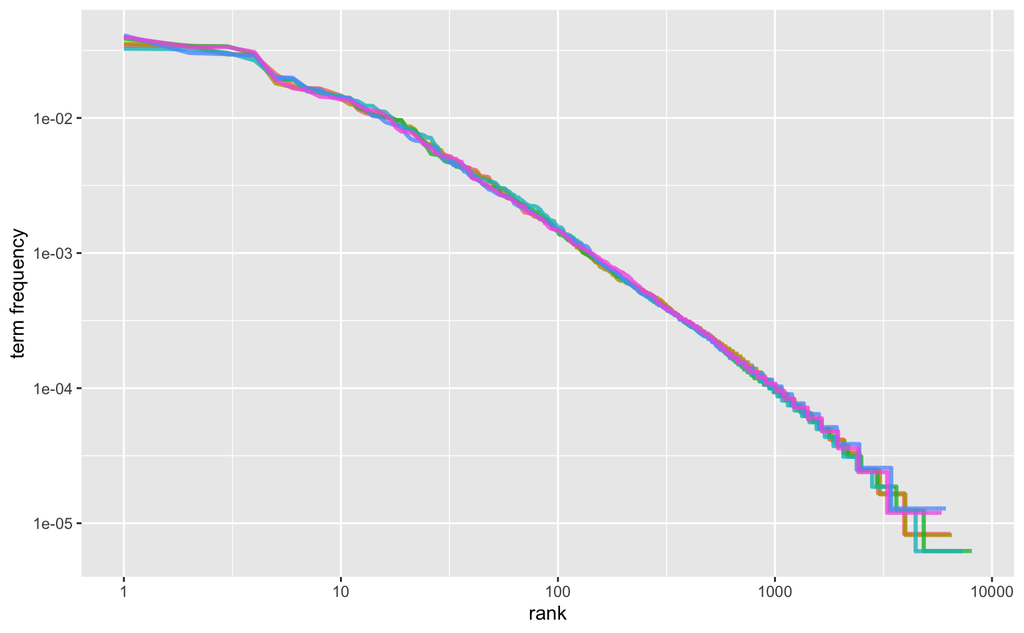

Zipf’s law for Jane Austen’s novels

```r
freq_by_rank %>%
    ggplot(aes(rank, `term frequency`, color = book)) +
    geom_line(size = 1.1,
              alpha = 0.8,
              show.legend = FALSE) +
    scale_x_log10() +
    scale_y_log10()
```

In log-log scale, we can see that the novels are similar, but the negative slope is not constant - as you’d see if a power law relationship applied. But the “middle” of this distribution does seem more constant. And, indeed, thje slope there is close to `-1`.

```r
rank_subset <- freq_by_rank %>%
    filter(rank < 500,
           rank > 10)

rank_lm <- lm(log10(`term frequency`) ~ log10(rank), data = rank_subset)
rank_lm
```

```
#>
#> Call:
#> lm(formula = log10(`term frequency`) ~ log10(rank), data = rank_subset)
#>
#> Coefficients:
#> (Intercept)  log10(rank)
#>     -0.6226      -1.1125
```

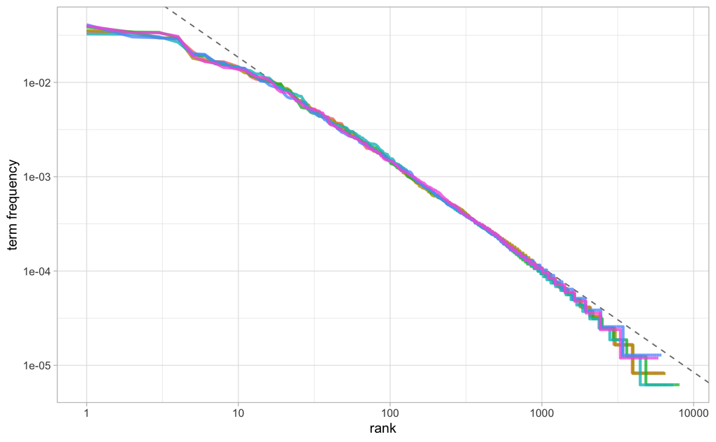

```r
freq_by_rank %>%
    ggplot(aes(rank, `term frequency`, color = book)) +
    geom_abline(
        intercept = rank_lm$coefficients[1],
        slope = rank_lm$coefficients[2],
        color = "gray50",
        linetype = 2
    ) +
    geom_line(size = 1.1,
              alpha = 0.8,
              show.legend = FALSE) +
    scale_x_log10() +
    scale_y_log10() +
    theme_light()
```

“The deviations we see here at high rank are not uncommon for many kinds of language; a corpus of language often contains fewer rare words than predicted by a single power law. The deviations at low rank are more unusual. Jane Austen uses a lower percentage of the most common words than many collections of language.”

## The `bind_tf_idf()` function

```r
book_tf_idf <- book_words %>%
    bind_tf_idf(word, book, n)

book_tf_idf %>%
    slice_max(n, n = 10) %>%
    kable()
```

| book | word | n | total | tf | idf | tf_idf |
| --- | --- | --- | --- | --- | --- | --- |
| Mansfield Park | the | 6206 | 160460 | 0.0386763 | 0 | 0 |
| Mansfield Park | to | 5475 | 160460 | 0.0341207 | 0 | 0 |
| Mansfield Park | and | 5438 | 160460 | 0.0338901 | 0 | 0 |
| Emma | to | 5239 | 160996 | 0.0325412 | 0 | 0 |
| Emma | the | 5201 | 160996 | 0.0323052 | 0 | 0 |
| Emma | and | 4896 | 160996 | 0.0304107 | 0 | 0 |
| Mansfield Park | of | 4778 | 160460 | 0.0297769 | 0 | 0 |
| Pride & Prejudice | the | 4331 | 122204 | 0.0354407 | 0 | 0 |
| Emma | of | 4291 | 160996 | 0.0266528 | 0 | 0 |
| Pride & Prejudice | to | 4162 | 122204 | 0.0340578 | 0 | 0 |

“Notice that idf and thus tf-idf are zero for these extremely common words. These are all words that appear in all six of Jane Austen’s novels, so the idf term (which will then be the natural log of 1) is zero.”

The high tf-idf words are shown like this.

```r
book_tf_idf %>%
    select(-total) %>%
    arrange(desc(tf_idf)) %>%
    slice_max(tf_idf, n = 10) %>%
    kable()
```

| book | word | n | tf | idf | tf_idf |
| --- | --- | --- | --- | --- | --- |
| Sense & Sensibility | elinor | 623 | 0.0051935 | 1.791759 | 0.0093056 |
| Sense & Sensibility | marianne | 492 | 0.0041015 | 1.791759 | 0.0073488 |
| Mansfield Park | crawford | 493 | 0.0030724 | 1.791759 | 0.0055050 |
| Pride & Prejudice | darcy | 373 | 0.0030523 | 1.791759 | 0.0054689 |
| Persuasion | elliot | 254 | 0.0030362 | 1.791759 | 0.0054401 |
| Emma | emma | 786 | 0.0048821 | 1.098612 | 0.0053635 |
| Northanger Abbey | tilney | 196 | 0.0025199 | 1.791759 | 0.0045151 |
| Emma | weston | 389 | 0.0024162 | 1.791759 | 0.0043293 |
| Pride & Prejudice | bennet | 294 | 0.0024058 | 1.791759 | 0.0043106 |
| Persuasion | wentworth | 191 | 0.0022831 | 1.791759 | 0.0040908 |

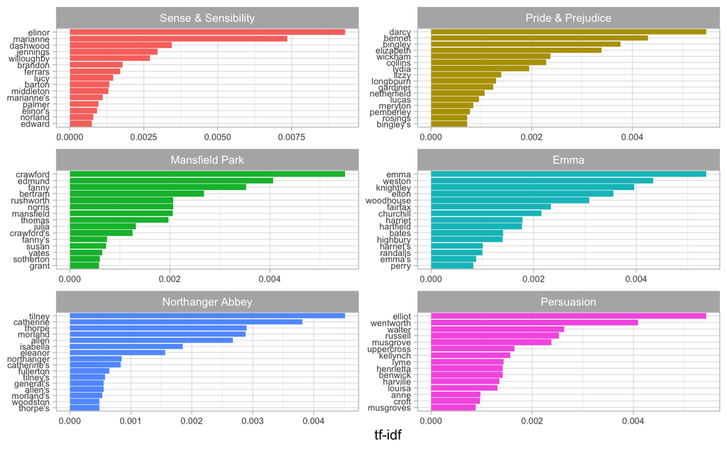

```r
book_tf_idf %>%
    group_by(book) %>%
    slice_max(tf_idf, n = 15) %>%
    ungroup() %>%
    ggplot(aes(tf_idf, fct_reorder(word, tf_idf), fill = book)) +
    geom_col(show.legend = FALSE) +
    facet_wrap( ~ book, ncol = 2, scales = "free") +
    labs(x = "tf-idf", y = NULL) +
    theme_light() +
    theme(axis.text = element_text(size = 7))
```

“What measuring tf-idf has done here is show us that Jane Austen used similar language across her six novels, and what distinguishes one novel from the rest within the collection of her works are the proper nouns, the names of people and places. This is the point of tf-idf; it identifies words that are important to one document within a collection of documents.”

## A corpus of physics texts

The following analyses uses some classis physics text available from [*Project Gutenberg*](https://www.gutenberg.org). We will use *Discourse on Floating Bodies* by Galileo Galilei (ID = 37729), *Treatise on Light* by Christiaan Huygens (ID = 14725), *Experiments with Alternate Currents of High Potential and High Frequency* by Nikola Tesla (ID = 13476), and *Relativity: The Special and General Theory* by Albert Einstein (ID = 30155).

```r
physics <- gutenberg_download(c(37729, 14725, 13476, 30155),
                              meta_fields = "author")

physics_words <- physics %>%
  unnest_tokens(word, text) %>%
  count(author, word, sort = TRUE)

physics_words %>%
    slice_max(n, n = 10) %>%
    kable()
```

| author | word | n |
| --- | --- | --- |
| Galilei, Galileo | the | 3760 |
| Tesla, Nikola | the | 3604 |
| Huygens, Christiaan | the | 3553 |
| Einstein, Albert | the | 2993 |
| Galilei, Galileo | of | 2049 |
| Einstein, Albert | of | 2028 |
| Tesla, Nikola | of | 1737 |
| Huygens, Christiaan | of | 1708 |
| Huygens, Christiaan | to | 1207 |
| Tesla, Nikola | a | 1176 |

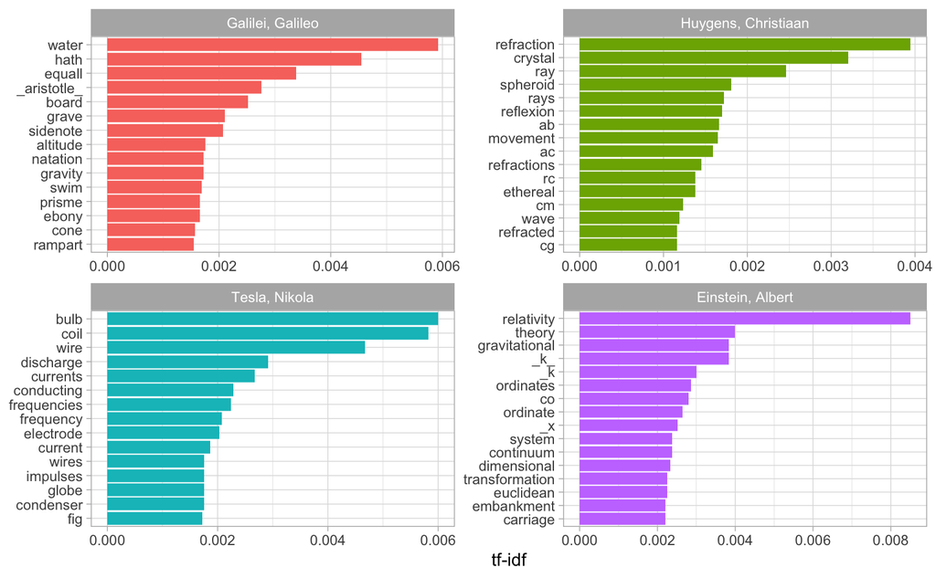

```r
plot_physics <- physics_words %>%
    bind_tf_idf(word, author, n) %>%
    mutate(author = factor(
        author,
        levels = c(
            "Galilei, Galileo",
            "Huygens, Christiaan",
            "Tesla, Nikola",
            "Einstein, Albert"
        )
    ))

plot_physics %>%
    group_by(author) %>%
    slice_max(tf_idf, n = 15) %>%
    ungroup() %>%
    mutate(word = reorder(word, tf_idf)) %>%
    ggplot(aes(tf_idf, word, fill = author)) +
    geom_col(show.legend = FALSE) +
    labs(x = "tf-idf", y = NULL) +
    facet_wrap( ~ author, ncol = 2, scales = "free") +
    theme_light()
```

In the examples, we see some technical terms (‘*k*’, ‘AB’, “RC’, etc.) that we might want to”clean up“. And we see that the term ‘co-ordinate’ was broken up by the tokenizer into ‘co’ and ‘ordinate’. We”clean up" these terms below.

```r
physics %>%
    filter(str_detect(text, "_k_")) %>%
    select(text) %>%
    slice_sample(n = 10) %>%
    kable()
```

| text |
| --- |
| the crystal at K_k_, all the points of the wave CO_oc_ will have |
| CO_oc_ in the crystal, when O_o_ has arrived at K_k_, because it forms |
| O_o_ has reached K_k_. Which is easy to comprehend, since, of these |
| necessarily be equal to CD, because C_k_ is equal to CK, and C_g_ to |
| ρ is the average density of the matter and *k* is a constant connected |
| would needs be that from all the other points K_k_B there should |
| surface AB at the points AK_k_B. Then instead of the hemispherical |

```r
physics %>%
    filter(str_detect(text, "RC")) %>%
    select(text) %>%
    slice_sample(n = 10) %>%
    kable()
```

| text |
| --- |
| tangent of the complement of the angle RCV, which is 73 degrees 20 |
| the angle RCG of 73 degrees 20 minutes, inclining to the same side as |
| this will be the required refraction of the ray RC. Which is |
| be described, cutting the ray RC at R; and let RV be the perpendicular |
| minutes, is to the radius of the Tables. Whence it appears that RCIT |
| ray RC, since IB is equal to CK, and IA equal to KO, and the angles A |
| plane AFHE, the incident ray RC; it is required to find its refraction |
| to CV. But KO is equal to N, and RC to CG: then as CK is to N so will |
| equally inclined, but coming from opposite sides, as here the rays RC, |
| the ray RC and through CK, is also given; from which it will be easy |

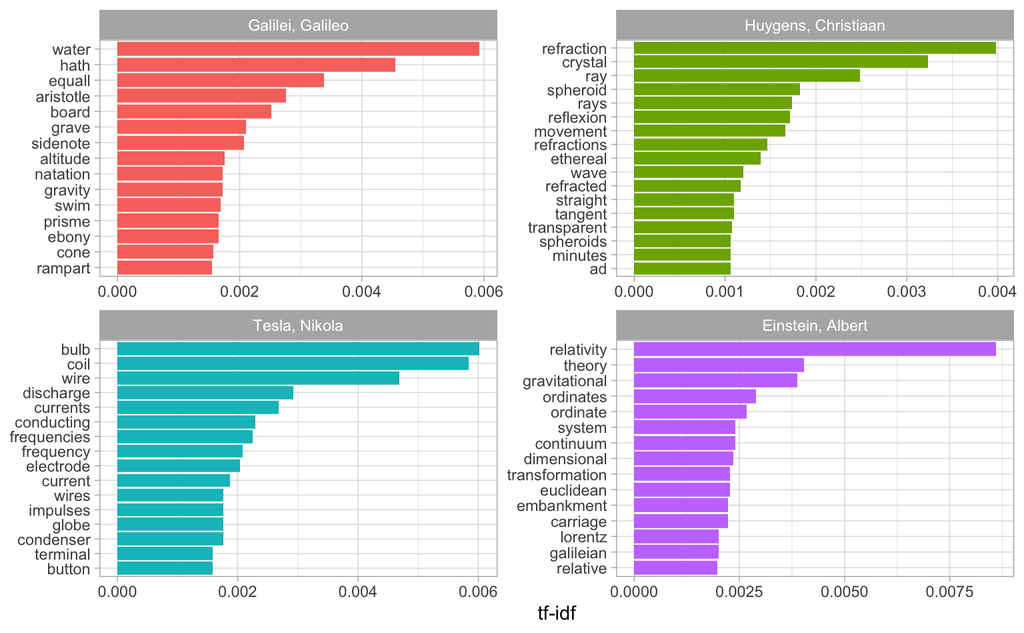

```r
mystopwords <- tibble(
    word = c(
        "eq", "co", "rc", "ac", "ak",
        "bn", "fig", "file", "cg", "cb",
        "cm", "ab", "_k", "_k_", "_x"
    )
)

physics_words <- anti_join(physics_words, mystopwords,
                           by = "word")

plot_physics <- physics_words %>%
    bind_tf_idf(word, author, n) %>%
    mutate(word = str_remove_all(word, "_")) %>%
    group_by(author) %>%
    slice_max(tf_idf, n = 15) %>%
    ungroup() %>%
    mutate(word = reorder_within(word, tf_idf, author)) %>%
    mutate(author = factor(
        author,
        levels = c(
            "Galilei, Galileo",
            "Huygens, Christiaan",
            "Tesla, Nikola",
            "Einstein, Albert"
        )
    ))

ggplot(plot_physics, aes(word, tf_idf, fill = author)) +
    geom_col(show.legend = FALSE) +
    labs(x = NULL, y = "tf-idf") +
    facet_wrap( ~ author, ncol = 2, scales = "free") +
    coord_flip() +
    scale_x_reordered() +
    theme_light()
```